# Beyond NB: Introduction to Bayesian networks

# Motivation behind bayesian networks:

Bayesian Networks allow us to make inference on a set of unknown variables in the presence of changing evidence, making it more suitable for understanding causal relationships. The theory behind BNs has been applied to several topics in Deep Learning, such as Deep Boltzmann Machines and Deep Belief Networks. The need is to build a model to represent several variables that interact among themselves, one approach is to model the joint probability distribution over variables of interest. Bayesian Networks are a type of probabilistic model, probabilistic models are especially useful when the features change in real time and we need to update our beliefs about underlying variables (like parent variables in a Bayesian Network) as new data arrives. We shall see later how Bayesian Inference allows for this.

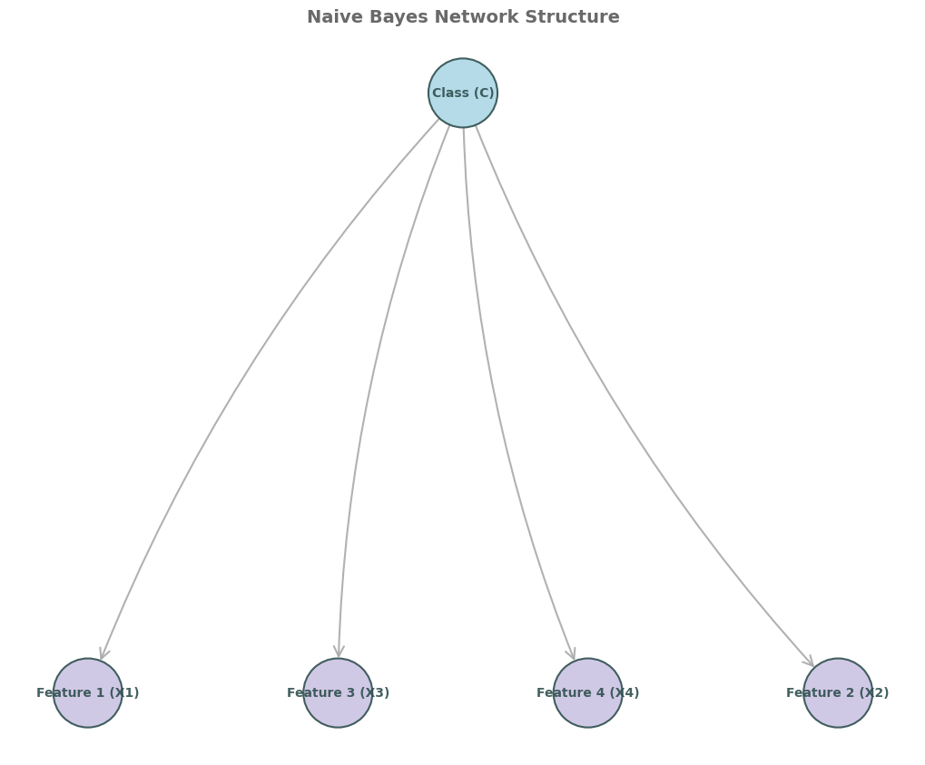

# A simple Naive Bayes Network -

A Naive Bayes model is a very specific and simple case of a Bayesian network. In Naive Bayes, the class variable (often called the parent node) is the only parent of all feature variables, and there are no edges between features. The model assumes that all features are **conditionally independent** given the class, i.e their probabilities given the class, can be multiplied as shown.

**Mathematical Formulation**

$For\ a\ naive\ Bayes\ model\ with\ class\ random\ variable\ C,\ and\ \ features\ X_{1},\ X_{2},......\ X_{n}$,

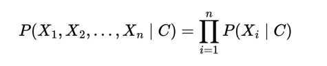

# Towards Bayesian Networks….

A Bayesian Network is a generalized [**probabilistic**](https://www.alphanome.ai/post/probabilistic-vs-deterministic-models-in-ai-ml-a-detailed-explanation) graphical model that allows for the explicit representation of dependencies among random variables—including features and class variables—through a directed acyclic graph (DAG).The nodes describe the variables, and the edges mean the conditional relationship.

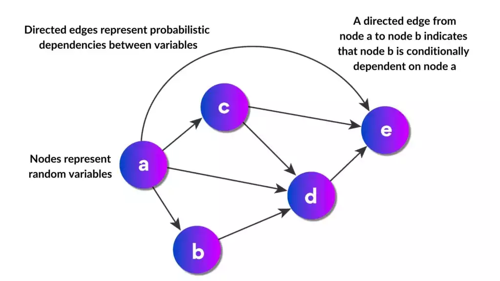

*Figure 1: Source: Spot Intelligence, 2024. [https://spotintelligence.com/2024/02/06/bayesian-network](https://spotintelligence.com/2024/02/06/bayesian-network/*)*

So, unlike Naive Bayes, which enforces strict conditional independence among features given the class, a Bayesian network can model any pattern of conditional dependencies and interdependencies among variables as specified by the graph structure.

**Mathematical Formulation of Bayesian Networks:**

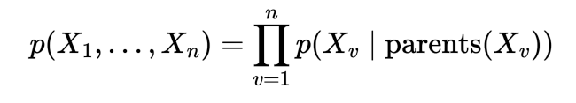

Therefore, the joint probability distribution of all variables $X_{1}$ to $X_{n}$ in a Bayesian network is equal to the product of the conditional probability of each variable given its parents in the network, which can be other variables as well.

## Example:

Characters and Variables:

- Rain (R): Is it raining today? (Yes/No) P(R = True) = 0.2
- Sprinkler (S): Did the gardener turn on the sprinkler? (Yes/No) P(S = True) = 0.4
- Wet Grass (G): Is the grass wet? (Yes/No)

Imagine in the morning, you find the grass is wet. You know two possible causes:

1. It rained last night.
2. The gardener turned on the sprinkler.

You also know that if it rains, the gardener usually does not turn on the sprinkler.

**Bayesian Network Structure:**

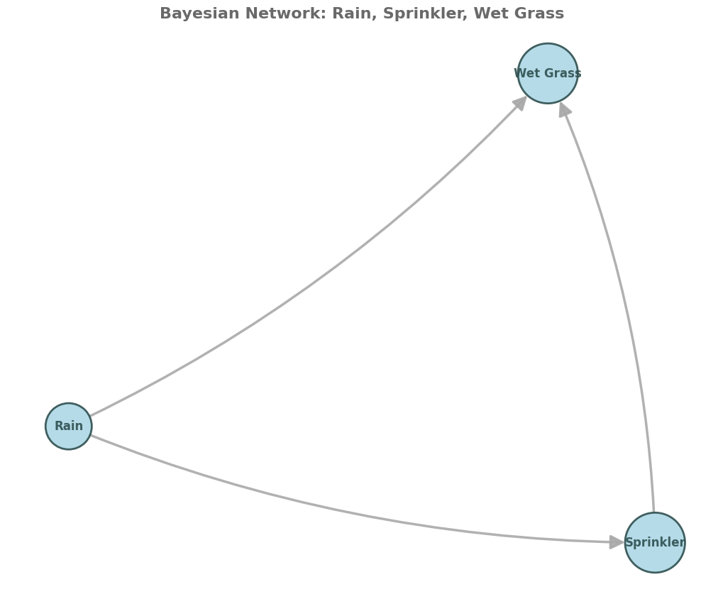

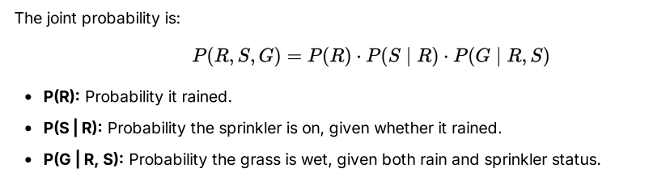

Hence, the Bayesian Network allows us to factorise the joint distribution P(R, S, G).

A Bayesian network is based on the “**local Markov**” property, which states that *each node is conditionally independent of its non-descendants given its parents*. This means that, if you know the values of a node’s parents, you do not need to know the values of its non-descendants to determine its probability distribution.

But nodes of a DAG are not the only thing that is needed in a Bayesian Network. Every node has a **Conditional Probability Distribution** (CPD) (or Conditional Probability Table, in case of discrete variables) associated with it.

Nodes which do not depend on any parent node, need to have a probability distribution (unconditional) of their own, or a probability for each value of the variable, in case it is discrete.

For nodes depending on one or more parents, their CPD’s must be defined corresponding to the probability of that variable given every possible combination of values of the parent node.

In the context of our example, this would be

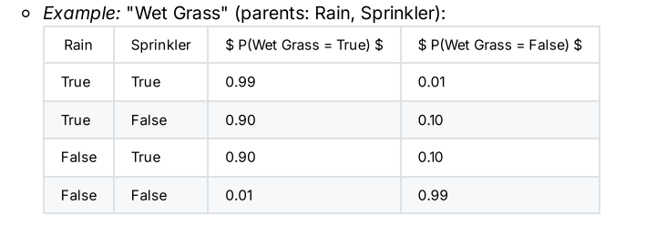

# Reasoning in Bayesian Networks:

In a Bayesian network, each node’s conditional probability distribution (CPT) only specifies the probability of that node given its parents. The CPT does not directly give us the posterior probability of parents given evidence about child nodes. We cannot look up the reverse probability (parents given children) directly in the CPT.

To obtain the posterior probability of parents given children (for example, the probability that it rained given that the grass is wet), we must use **Bayesian inference**. This means applying Bayes’ theorem or other inference algorithms to update our beliefs about the parents based on observed evidence about the children.

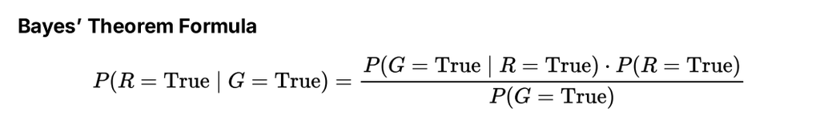

[figure not shown]

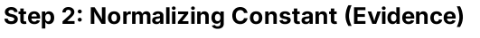

[figure not shown]

This can be calculated from the CPT of node Wet Grass

P(G = True) = 0.99x0.2x0.4 + 0.90x0.2x0.6 + 0.90x0.8x0.4 + 0.01x0.8x0.6 = 0.48

An interesting property of BN’s is Inter Causal Reasoning [ J.Pearl, 1988]. This property means that, when we have two possible causes, if we know that one is true, naturally we assign less probability to the other. For example, if we find that the grass is wet, and we know the reason for it to be the sprinkler, we assign less probability to rain.

Till now, we have discussed the most naive way to calculate the probability distributions of child nodes. This technique doesn’t take into account some implementation tips, such as to reuse some factors previously calculated. The use of implementation tips is known as **Variable Elimination Algorithm**. The **junction tree algorithm** is an **exact-inference technique** that uses dynamic programming to efficiently perform computations for inference.

However, for most real - world scenarios, we use approximate inference algorithms.

# Variable Elimination

Variable Elimination is an exact inference algorithm used to compute posterior probabilities in Bayesian Networks. Let’s take our example of wet grass, to understand the algorithm.

First, for each node in the BN we create a function that represents the conditional probability table (CPT) for that node given its parents.

$1.\ f_{R}(R)\ = \ P(R)$

$3.\ f_{G}(R,S,G)\ = \ P(G\ |\ R,S)$

Instantiate evidence set G = True in $f_{G}$

*P*(*G*=true)=*P*(*G*=true∣*R*,*S*)⋅*P*(*R*=true)⋅*P*(*S*=true)+*P*(*G*=true∣*R*,*S*)⋅*P*(*R*=true)⋅*P*(*S*=false)+*P*(*G*=true∣*R*,*S*)⋅*P*(*R*=false)⋅*P*(*S*=true)+*P*(*G*=true∣*R*,*S*)⋅*P*(*R*=false)⋅*P*(*S*=false)

Then we need to choose an elimination order. Say we first choose to eliminate S.

Using Total Probability Theorem,

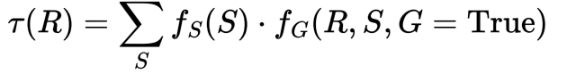

*τ*(*R*)=*P*(*S*=true)⋅*P*(*G*=true∣*R*,*S*=true)+*P*(*S*=false)⋅*P*(*G*=true∣*R*,*S*=false)

Next multiply remaining factors

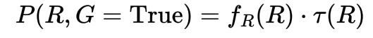

If we set R=true once, and R=false once, and sum up, we will recover our original expression of P(G=True). But now, the variable S has been eliminated.

Normalize the expression.

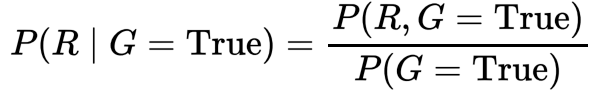

Thus we get our final result, the aim of variable elimination in a Bayesian network, that is to compute the marginal probability of our query variables given any evidence.

For a more complex example of Variable Elimination refer to this link : [Medium article on Variable Elimination](https://expleogroup.medium.com/introduction-to-bayesian-networks-and-predictive-maintenance-part-1-831d22cad158)

# Junction Tree Algorithm

Variable elimination is a powerful way to compute marginal probabilities in Bayesian networks, but it’s designed for one query at a time—each new query requires running the whole process again. To make inference more efficient for multiple queries, we can generalize variable elimination by organizing the computation into a tree of clusters, known as a junction tree. Junction Tree uses the same calculations as variable elimination but uses dynamic programming to store the calculated probability distributions (potentials).

For a detailed implementation of the Junction Tree Algorithm, follow this link :

[Medium article on junction tree algorithm](https://medium.com/@miltonleal/probabilistic-inference-the-junction-tree-algorithm-and-the-chest-clinic-problem-66241417addc)

# Approximate Inference Algorithms

There are many approximate inference algorithms for Bayesian networks.  
The two simplest ones are rejection sampling, and likelihood weighting algorithm.

## **Rejection Sampling (Logic Sampling)**

To estimate a conditional probability using rejection sampling, you proceed as follows:

1. **Generate Samples:**  
   Draw a set of samples from the Bayesian network. Each sample is created by simulating the network: you start from nodes with no parents, sample their values, and then sample each child node in sequence, always using the sampled values of its parents.
2. **Filter by Evidence:**  
   From this collection, discard any sample that does not match the observed evidence (i.e., where the evidence variables do not take the specified values).
3. **Estimate Probabilities:**  
   Use the remaining samples to approximate the conditional distribution of your query variable. If the variable is discrete, simply count how often each possible value appears in the filtered samples and divide by the total number of retained samples.

This approach is straightforward but often inefficient, especially when the evidence is rare. Many samples are generated only to be discarded, which can waste computational resources.

## **Likelihood Weighting**

Likelihood weighting is a more efficient sampling method that avoids outright rejection of samples:

1. **Sample with Evidence Fixed:**  
   When generating samples, you always set the evidence variables to their observed values. For all other variables, you sample values in the usual way, from top to bottom, using the sampled values of their parents.
2. **Assign Weights:**  
   Each sample is assigned a weight based on the probability of the observed evidence given its parents. Specifically, the weight is the product of the probabilities that the evidence variables would have taken their observed values, given their parents, for each sample.
3. **Estimate Probabilities:**  
   All samples are used to estimate the conditional distribution of the query variable, but each sample is weighted. For a discrete query variable, the estimate is obtained by averaging the weights of samples that correspond to each possible value of the query variable.

For an introduction to all methods of approximate inference refer to this link: [Approximate Inference Algorithms](https://www.geeksforgeeks.org/artificial-intelligence/approximate-inference-in-bayesian-networks/)

Check out this kaggle resource for simple code implementations of bayesian networks:

https://www.kaggle.com/code/dhruvdeshmukh/constructing-the-bayesian-networks-in-python